## 옵션 익히기 2

코드 청크가 자신이 가지고 있는 소스코드를 출력으로 할지 여부를 제어할 수 있다. 이것은 echo 옵션으로 TRUE 나 FALSE 혹은 숫자 값을 정할 수 있다. 디폴트는 TRUE 다. echo=TRUE 면 출력하고 FALSE 는 출력하지 않는다. 숫자 값은 코드의 일부만 출력할 때 사용한다. 예를 들어 echo=1:3 이면 1에서 3번 줄까지를 echo=-2는 2번줄을 제외하라는 의미이다. ehco=(1,3)은 1번과 3번줄을 출력 하라는 의미이다.

다음과 같이 히스토그램을 그린다.

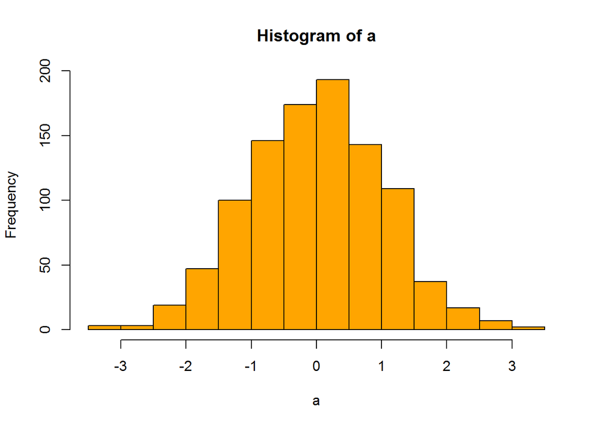

ggplot2로 같은 히스토그램을 그린다.

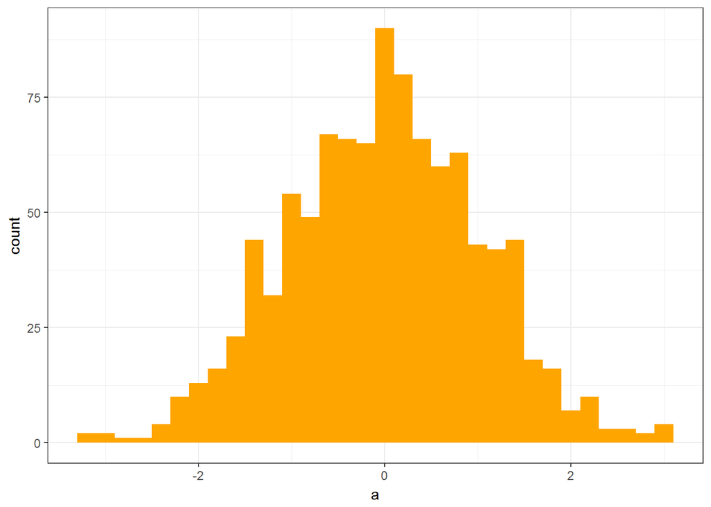

```r
P<-ggplot(as.data.frame(a),aes(a))
P<-P+geom_histogram(binwidth=0.2,fill='orange')
P<-P+theme_bw()
P
```

# 옵션 익히기

코드 청크가 어떤 조건에 맞을 때만 실행되도록 할 수 있다. 처음 코드는 일종의 조절자 역할을 한다. 세번째 코드 청크에서는 ! 여산자를 사용해 부정하고 있다.

```r
dothis<-TRUE
```

참 이므로 결과로 실행

```r
head(iris)
```

```
##   Sepal.Length Sepal.Width Petal.Length Petal.Width Species
## 1          5.1         3.5          1.4         0.2  setosa
## 2          4.9         3.0          1.4         0.2  setosa
## 3          4.7         3.2          1.3         0.2  setosa
## 4          4.6         3.1          1.5         0.2  setosa
## 5          5.0         3.6          1.4         0.2  setosa
## 6          5.4         3.9          1.7         0.4  setosa
```

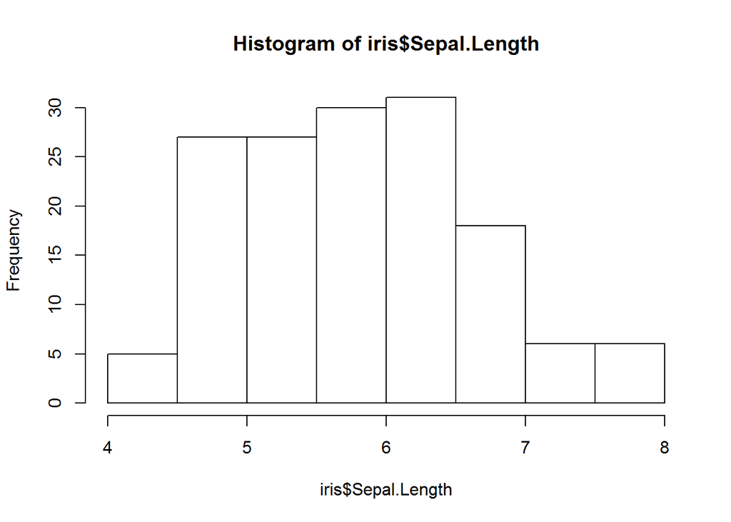

```r
hist(iris$Sepal.Length)
```

거짓 이므로 코드만 보임

```r
head(iris)
hist(iris$Sepal.Length)
```

# 옵션 익히기 3

```r
a<-sample(1:10, 10, replace=TRUE)
f<-function(x){m<-mean(x); s<-sd(x); v<-var(x)
return(list(mean=m, sd=s, var=v))}

a
```

```
##  [1]  3  5 10  3  9  4 10  2  4  2
```

```r
f(a)
```

```
## $mean
## [1] 5.2
##
## $sd
## [1] 3.224903
##
## $var
## [1] 10.4
```

@다음은 ‘prompt=TRUE , tidy=FALSE’ 로 주었다. @

```r
> a<-sample(1:10,10,replace = TRUE)
> f<-function(x){m<-mean(x); s<-sd(x); v<-var(x)
+ return(list(mean=m, sd=s, var=v))}
>
> a
```

```
 [1]  5  5  1 10  9  1  8  5  8  8
```

```r
> f(a)
```

```
$mean
[1] 6

$sd
[1] 3.162278

$var
[1] 10
```

# 결과 텍스르를 보낼 방법 결정하기:results

```r
kable(head(iris))
```

| Sepal.Length | Sepal.Width | Petal.Length | Petal.Width | Species |
| --- | --- | --- | --- | --- |
| 5.1 | 3.5 | 1.4 | 0.2 | setosa |
| 4.9 | 3.0 | 1.4 | 0.2 | setosa |
| 4.7 | 3.2 | 1.3 | 0.2 | setosa |
| 4.6 | 3.1 | 1.5 | 0.2 | setosa |
| 5.0 | 3.6 | 1.4 | 0.2 | setosa |
| 5.4 | 3.9 | 1.7 | 0.4 | setosa |

```r
kable(head(iris))
```

| Sepal.Length | Sepal.Width | Petal.Length | Petal.Width | Species |
| --- | --- | --- | --- | --- |
| 5.1 | 3.5 | 1.4 | 0.2 | setosa |
| 4.9 | 3.0 | 1.4 | 0.2 | setosa |
| 4.7 | 3.2 | 1.3 | 0.2 | setosa |
| 4.6 | 3.1 | 1.5 | 0.2 | setosa |
| 5.0 | 3.6 | 1.4 | 0.2 | setosa |
| 5.4 | 3.9 | 1.7 | 0.4 | setosa |

```r
kable(head(iris))
```